# STSCI 5065 - Lecture 04

The Hadoop Distributed Filesystem (HDFS)

Harry Lu

# 1 HDFS

- **Distributed filesystems:** Filesystems that manage the storage across a network of machines. This is the only way to deal with the situation where a dataset outgrows the storage capacity of of a single physical machine
- **Hadoop Distributed Filesystem (HDFS):** A general purpose filesystem abstraction designed for storing very large files with streaming data access patterns, running on clusters of commodity hardware. It is Hadoop’s flagship filesystem. It can deal with both unstructured and structured data

# 2 Characteristics of HDFS

- **Highly Scalable:** can have a computer cluster from several to tens of thousands of nodes
- **Reliable:** tolerant to fault due to built-in redundancy
- **Massive parallel processing:** supports massive parallel processing with linearly scalable bandwidth
- **Very easy to manage:** it is managed automatically

# 3 Parallel Computing Paradigms

- **Shared memory** by partitioning work
- **Message passing** by partitioning data
- A hybrid of the two exists
- What Hadoop does is to use a higher level of abstraction than pure shared memory or massage passing. It is a message-passing, data parallel, and pipelined work paradigm. This is a new way of parallel computing. The beauty of the system is that all that complicated work is handled automatically

# 4 Areas where HDFS is a good fit

- **Very large files:** Hundreds of megabytes, gigabytes, or terabytes in size. There are Hadoop clusters running today that store petabytes of data
- **Streaming data access:** The most efficient data processing pattern: **write once, read many times**. Data analysis will involve a large proportion, if not all, of the dataset, so the time to read the whole dataset is more important than the latency in reading the first record
- **Using commodity hardware:** Cheaper. Although the chance of node failure is higher (at least for large clusters), HDFS is designed to carry on working without a noticeable interruption to the user in the face of such failure

# 5 Areas where HDFS is not a good fit today

- **Low-latency data access:** A requirement of tens of milliseconds range will not work well with HDFS since it is optimized for delivering a high throughput of data (at the expense of latency)
- **Lots of small files:** The namenode holds filesystem metadata in memory. The amount of this memory limits the number of files in a filesystem. While storing millions of files is feasible, storing billions of files is beyond the capability of current hardware
- **Multiple writers and arbitrary file modifications:** Files in HDFS may be written to by a single writer. Writes are always made at the end of the file. There is no support for multiple writers, or for modifications at arbitrary offsets in the file

# 6 Some Basic HDFS Concepts

- Filesystem options
- Blocks
- Namenodes and Datanodes
- HDFS High-Availability

## 6.1 The Underlying Filesystem Options

- ext3 (third extended file system) *Commonly used in HDFS*
  - Used by Yahoo
  - Released in 2001
  - Up to 32 TB of file size
- ext4 (fourth extended file system) *Commonly used in HDFS*
  - Used by Google
  - Released in 2008
  - Fast like XFS
  - Up to 1 EB (exabytes)
- XFS
  - Released in 1993 by Silicon Graphics
  - Fast (parallel I/O)
  - Some drawbacks (cannot be shrunk; slow metadata processing)

## 6.2 Blocks

- **Disk blocks:** The minimum amount of data that it can read or write, which is normally **512 bytes**
- **Filesystem blocks (on a single disk):** An integral multiple of the disk block size, typically **a few kilobytes** in size
- **HDFS blocks (abstraction):** Its size is a much larger unit - **64 MB** or **128 MB** by default. Files in HDFS are broken into block-sized chunks, stored as independent units. Unlike a filesystem for a single disk, a file in HDFS that is smaller than a single block does not occupy a full block’s worth of underlying storage

### 6.2.1 Why Is a Block in HDFS So Large?

- To minimize the cost of seeks. A large block size like this (128 or 64 MB) can make the time to transfer the data from the disk be significantly greater than the time to seek to the start of the block. Thus, the data transfer can operate at near the disk transfer rate
  - Example: *If the seek time is 10 ms and the transfer rate is 100 MB/s, to make the seek time 1% of the transfer time, the block size should be around 100 MB*
- The map tasks in MapReduce operate on one block at a time, so if you have too few tasks (fewer than nodes in the cluster), your jobs will run slower than they could otherwise

### 6.2.2 Benefits of block abstraction for an HDFS

- A file can be larger than any single disk in the network
- Making the unit of abstraction a block simplifies the storage subsystem (it is easy to calculate how many blocks can be stored on a given disk)
- Blocks fit well with replication for providing fault tolerance and availability. Each block is replicated to a small number (typically 3) of physically separate machines. If a block becomes unavailable, a copy can be read from another location in a way that is transparent to the client. A block that is no longer available due to failure can be replicated from its alternative locations to other live machines to bring the replication factor back to the normal level
- The fsck command in HDFS understands blocks. For example, running: `hdfs fsck / -files -blocks` will list the blocks of all the files in the filesystem

### 6.2.3 A Hadoop Cluster

- A Hadoop cluster is composed of a Name Node and a cluster of Data Nodes

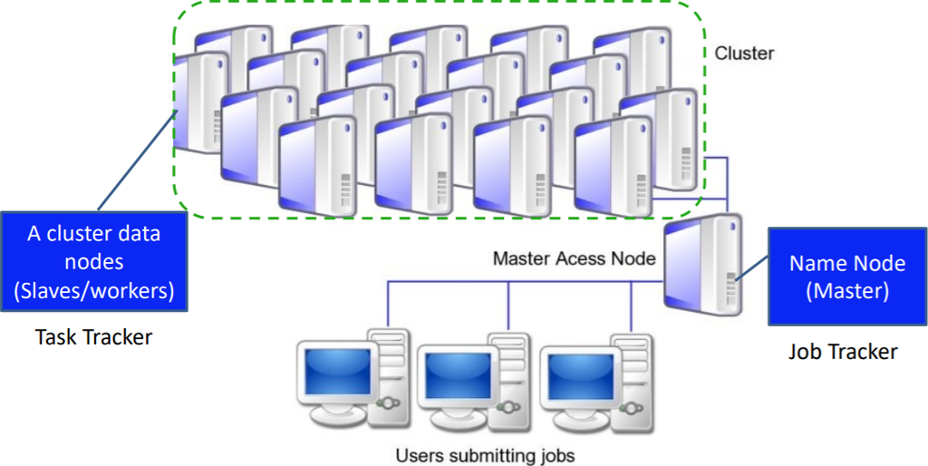

## 6.3 Name Nodes and Data Nodes

- The **name node** manages the filesystem namespace. It maintains the **filesystem tree** and the **metadata** (held in memory). This information is stored persistently on the local disk: the **namespace image** and the **edit log**. The name node knows the locations of all the blocks of a given file. It is reconstructed from data nodes when the system starts
- **Data nodes** are the workhorses of the filesystem. They store and retrieve blocks when they are told to (by clients or the name node), and they report back to the name node periodically with lists of blocks that they are storing

### 6.3.1 The Importance of the Name Node

Without the name node, the filesystem has no use (a single point of failure, or SPOF). It is critical to make this node resilient to failure. There are two mechanisms

- **Back up the files that make up the persistent state of the filesystem metadata**. The name node writes its persistent state to multiple file systems, the local disk as well as a remote NFS mount
- **Run a secondary name node**. Despite its name, in Hadoop 1 it did not act as a name node (just a checkpoint) but periodically merges the namespace image with the edit log, which can be used to rebuild a new name node if a total failure of name node happens

## 6.4 HDFS High-Availability

- Hadoop 2 implements a pair of name nodes in an activestandby configuration as a standard operational procedure. If the active name node does fail, the standby can take over quickly (in a few tens of seconds)
- Data nodes send block reports to both name nodes since the block mapping is stored in the memory of name nodes
- Only one name node is active at a time
- Each name node runs a failover controller process to monitor its health by using the heartbeating mechanism
- A fencing mechanism is used to prevent a failing primary name node from damaging the cluster by killing all its processes or even “shooting the other node in the head” (cut the power)

# 7 The Name Node Holds the Metadata

- Names of the files
- Data blocks of each file
- File system permissions
- Last access time
- Disk space quotas
- …

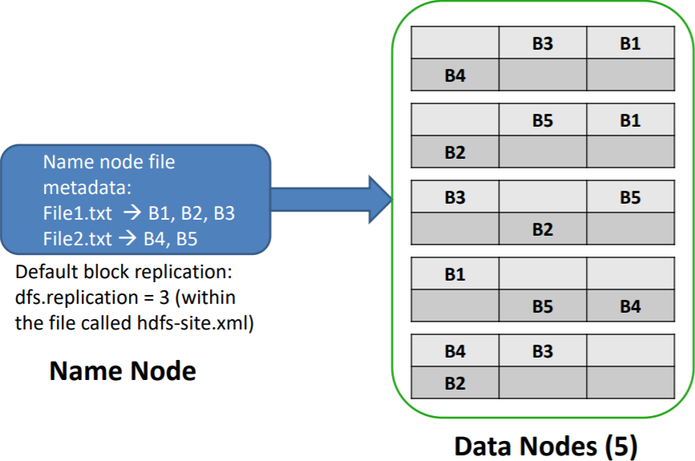

# 8 The Name Node Has an Embedded Web Server

It shows some statistics of the filesystem:

- Time the name node started, version, time of compilation
- Name node logs
- Cluster summary, such as
  - Number of files and directories blocks
  - Configured capacity
  - DFS used
  - DFS remaining
  - Live nodes
  - Dead nodes
- Name node storage
  - Storage directory
  - Type
  - State

# 9 An Example of Name Node Statistics

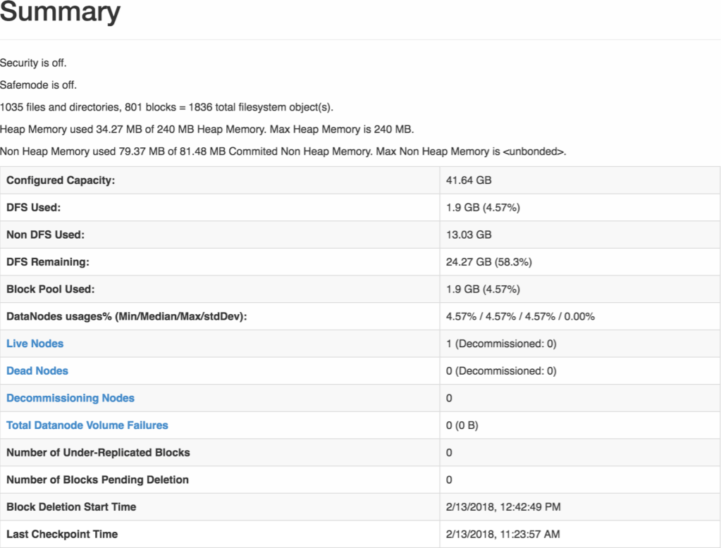

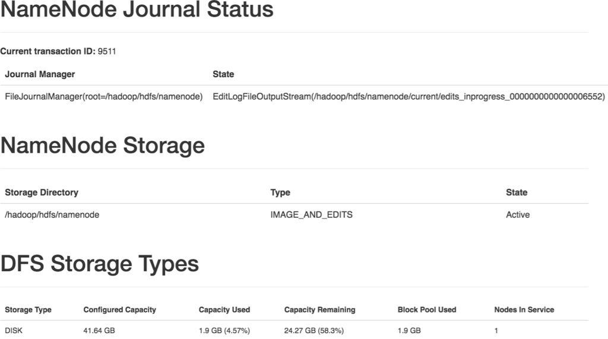

# 10 A Diagram of a HDFS Cluster

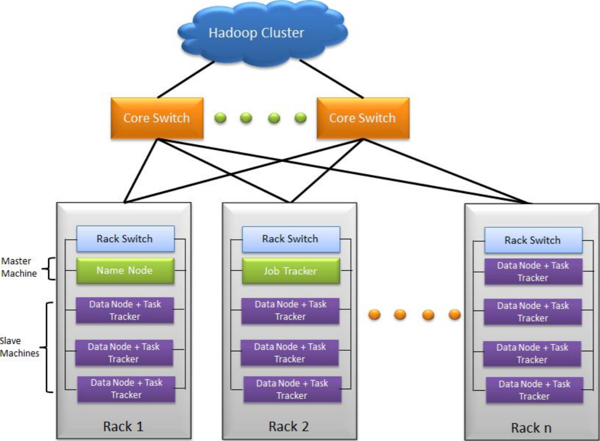

# 11 Network Distance in an HDFS Cluster

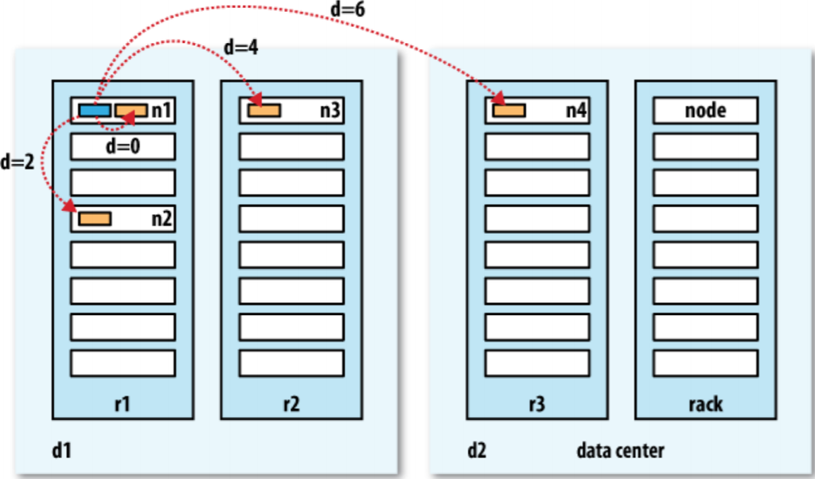

Use the bandwidth between two nodes as a measure of distance:

- distance(/d1/r1/n1, /d1/r1/n1) = 0 (processes on the same node)
- distance(/d1/r1/n1, /d1/r1/n2) = 2 (different nodes on the same rack)
- distance(/d1/r1/n1, /d1/r2/n3) = 4 (different racks in the same data center)
- distance(/d1/r1/n1, /d2/r3/n4) = 6 (in different data centers)

# 12 Name Node is Rack Aware

- Allows consideration of a node’s physical location, when allocating storage and scheduling tasks
- Can diagnose the health of the files system and can rebalance the data on different nodes
- Handles different types of cluster that might otherwise require operator intervention. This design allows a single operator to maintain a cluster of 1000s of nodes

# 13 Basic Filesystem Operations

- In the Filesystem, we can do all of the usual operations, such as reading files, creating directories, moving files, deleting data, and listing directories
- This is through Hadoop’s filesystem shell command `fs`, which supports many subcommands, e.g., `-mkdir`
- You can type `hadoop fs -help` to get detailed help on every command
- The files in HDFS are not visible with your normal Linux/Unix commands due to different URI schemes

# 14 Some Common Hadoop Commands

- `hadoop fs -ls`
  - List the contents that match the specified file pattern
- `hadoop fs -mkdir`
  - Create a directory in a specified location
- `hadoop fs -copyFromLocal` (= `hadoop fs -put`)
  - Copy a file(s) from the local system into HDFS
- `hadoop fs -copyToLocal` (= `hadoop fs -get`)
  - Copy a file(s) from HDFS to the local file system
- `hadoop fs -rm`
  - Delete all files matching the specified pattern
- `hadoop fs -mv`
  - Move files from a source to destination

# 15 Create an HDFS directory at System Root

- Create an HDFS directory, /stsci5065/data, at the CentOS root to hold your files

```
[root@sandbox ~]# hadoop fs -mkdir /stsci5065
[root@sandbox ~]# hadoop fs -mkdir /stsci5065/data
```

- This directory is not visible to normal Linux/Unix, for example, the `find` command cannot find it

```
[root@sandbox ~]# find /stsci5065/data
find: '/stsci5065/data': No such file or directory
```

- Neither does the `ls` command

```
[root@sandbox ~]# ls /stsci5065
ls: cannot access /stsci5065: No such file or directory
```

# 16 The New Directory is Visible in HDFS

- The stsci5065 directory can be shown with the HDFS’ `hadoop fs -ls` command

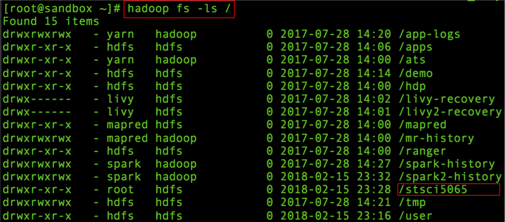

# 17 Download Some Data Files from Internet

```
wget http://www.gutenberg.org/files/100/100-0.txt
wget ftp://ftp.ncbi.nih.gov/genomes/INFLUENZA/influenza.cds
wget http://www.gutenberg.org/files/74/74-0.txt
```

Note:

- 100-0.txt (pg100.txt, shakespeare.txt)
- 74-0.txt (tom_sawyer.txt)